# Boat Types Image Classification Assignment3-Misra-BoatTypesRecognition

Shrawani Misra

12/4/2022

## **Boat Types Image Classification using Covnet model**

The purpose of this project is to classify what type of boat is based on its appearance. The convolutional neural network model that I create in the subsequent steps will determine if a boat belongs to one of the 9 main categories (buoy, cruise ship, ferry boat, freight boat, gondola, inflatable boat, kayak, paper boat, sailboat).

Broadly, we will be exploring feature extraction to possibly determine the distinguishing features and important portions of the images.

**Data Source** : Data has been sourced from kaggle (“https://www.kaggle.com/datasets/clorichel/boat-types-recognition”). The dataset contains approximately more than 1000 images in jpg format. So far there were no existing code notebooks for this data in the language R.

### **Project Coding**

Loading libraries required for the project; keras and tensorflow will be most helpful as we are exploring CNNs.

```r
library(keras)
library(reticulate)
library(tidyverse)
library(tensorflow)
```

```r
library(imager)
```

### **I. Data Extraction**

As the data is huge, upon downloading from kaggle it goes into a zip file. Once extracted, the folder is “archive” which subsequently contains folders titled with the types of boats.

```r
original_dataset_dir <- "archive" # we will only use the labelled data
base_dir <- "." # to store a sebset of data that we are going to use
```

Next, to explore data I make three separate folders for Training, Validation and Testing for all 9 different types of boats.

Creating folders and copying files to training, validation and testing folders. As a rule of thumb, I consider ~50% of data for training, ~30% for validation, ~20% for testing. Copying for 9 types of boats, the code snippet is included in R file.

### **II. Creating CNN model**

Building a keras model to recognize patterns. I first make layers of our data and then compile. As our case study is not an “either/or” case for merely 2 outcomes, but for 9 different outcomes, I use **categorical crossentropy loss, optimizer_adam optimizer** and **softmax activation** for our keras model

### **III. Data augmentation and pre-processing**

Reading image files, decoding from JPEG to RGB pixel grids, converting to floating-point kernels using Keras. I thus make three separate datagenerators for training, validation and testing and run the model in batches. The class mode I take for this case is categorical.

As there were overfitting issues, I used data augmentation to generate more samples from existing dataset.

```r
datagen <- image_data_generator(
  rescale = 1/255,
  rotation_range = 40, # randomly rotate images up to 40 degrees
  width_shift_range = 0.2, # randomly shift 20% pictures horizontally
  height_shift_range = 0.2, # randomly shift 20% pictures vertically
  shear_range = 0.2, # randomly apply shearing transformations
  zoom_range = 0.2, # randomly zooming inside pictures
  horizontal_flip = TRUE, # randomly flipping half the images horizontally
  fill_mode = "nearest" # used for filling in newly created pixels
)
```

```
## Loaded Tensorflow version 2.0.0
```

```r
#train_datagen <- image_data_generator(rescale = 1/255)
#validation_datagen <- image_data_generator(rescale = 1/255)
#test_datagen <- image_data_generator(rescale = 1/255)

train_generator <- flow_images_from_directory(
  "train/", # Target directory
  datagen, # Training data generator
  target_size = c(150, 150), # Resizes all images to 150 × 150
  batch_size = 20, # 20 samples in one batch
  class_mode = "categorical" # Because we use categorical_crossentropy loss,
  # we need categorical labels.
)

validation_generator <- flow_images_from_directory(
  "validation/",
  datagen,
  target_size = c(150, 150),
  batch_size = 20,
  class_mode = "categorical"
)

test_generator <- flow_images_from_directory(
  "test/",
  datagen,
  target_size = c(150, 150),
  batch_size = 20,
  class_mode = "categorical"
)
```

### **IV. Loading the saved history and model in R Markdown**

Saving the model as a h5 and history as a rds file I load them as my final model and plot the fit

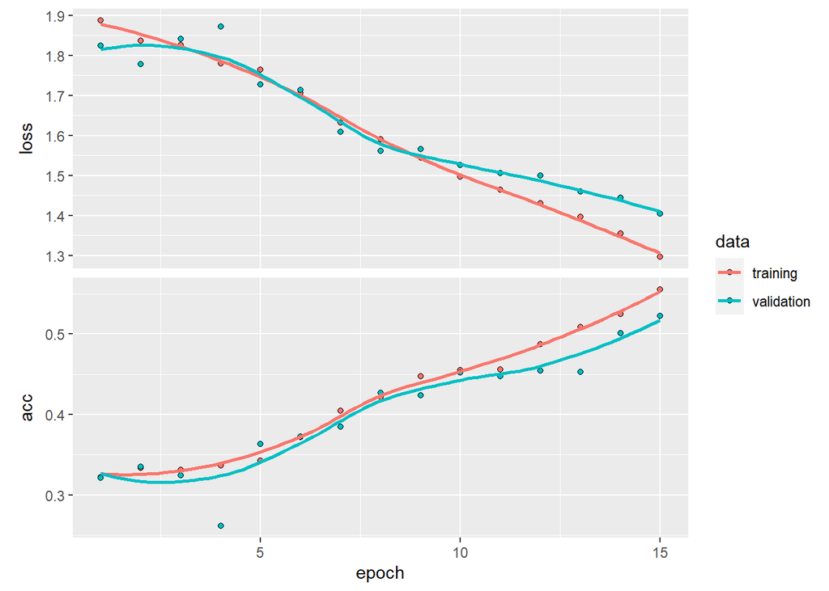

```r
model_file = "final_model.h5"
history_file = "model_history.rds"
model_final <- load_model_hdf5(model_file)
history_final <- read_rds(history_file)

plot(history_final)
```

**Evaluating the test data**

```r
model_final %>%
  evaluate_generator(test_generator, steps = 50)
```

```
## $loss
## [1] 1.457596
##
## $acc
## [1] 0.5232679
```

To avoid overfitting, there has been a trade-off with the accuracy of the model which may be worked upon later by increasing epochs. Due to bandwidth limit I have finished with a total of 15 epochs, working with 30 or 45 has been too cumbersome for the system.

Getting the folders in the training data.

```r
folder_list <- list.files("train/")
folder_list
```

```
## [1] "buoy"            "cruise ship"     "ferry boat"      "freight boat"
## [5] "gondola"         "inflatable boat" "kayak"           "paper boat"
## [9] "sailboat"
```

Getting the files and visualizing some images in image grids

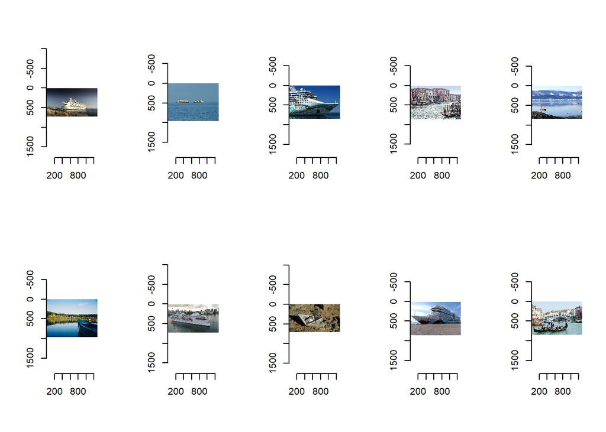

```
## [[1]]
## Image. Width: 1280 pix Height: 720 pix Depth: 1 Colour channels: 3
##
## [[2]]
## Image. Width: 1280 pix Height: 960 pix Depth: 1 Colour channels: 3
##
## [[3]]
## Image. Width: 1280 pix Height: 851 pix Depth: 1 Colour channels: 3
##
## [[4]]
## Image. Width: 1280 pix Height: 854 pix Depth: 1 Colour channels: 3
##
## [[5]]
## Image. Width: 1280 pix Height: 833 pix Depth: 1 Colour channels: 3
##
## [[6]]
## Image. Width: 1280 pix Height: 961 pix Depth: 1 Colour channels: 3
##
## [[7]]
## Image. Width: 1280 pix Height: 720 pix Depth: 1 Colour channels: 3
##
## [[8]]
## Image. Width: 1280 pix Height: 708 pix Depth: 1 Colour channels: 3
##
## [[9]]
## Image. Width: 1280 pix Height: 853 pix Depth: 1 Colour channels: 3
##
## [[10]]
## Image. Width: 1280 pix Height: 851 pix Depth: 1 Colour channels: 3
```

```r
folder_path <- paste0("train/", folder_list, "/")
file_name <- map(folder_path,
                 function(x) paste0(x, list.files(x))) %>%
  unlist()
sample_image <- sample(file_name, 10)

# Load image into R
img <- map(sample_image, load.image)
# Plot image
par(mfrow = c(2, 5)) # Create 4 x 5 image grid
map(img, plot)
```

Thus, this model can determine based on distinguishing features of a given boat what type of boat it may be. Sometimes, misclassifications may occur but the model will give an accurate result 52% of the time.

*Showing Proof there is no R code file existing for this dataset on Kaggle.*

[figure not shown]